# R Notebook

GUIA 5 EJERCICIO 1

```r
library(bayesrules)
library(tidyverse)
library(rstan)
library(rstanarm)
library(bayesplot)
library(tidybayes)
library(janitor)
library(broom.mixed)
library(palmerpenguins)
require(brms)
library(ggplot2)
library(mltools)
library(data.table)
```

[output not shown]

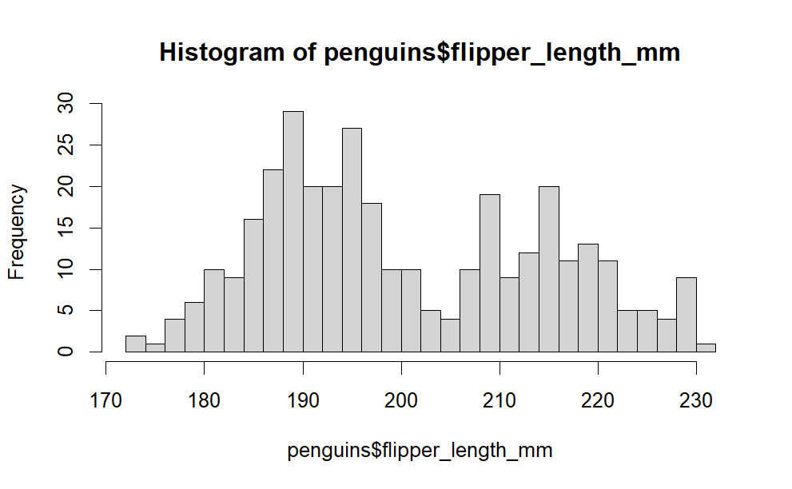

```r
(hist(penguins$flipper_length_mm, breaks = 40))
```

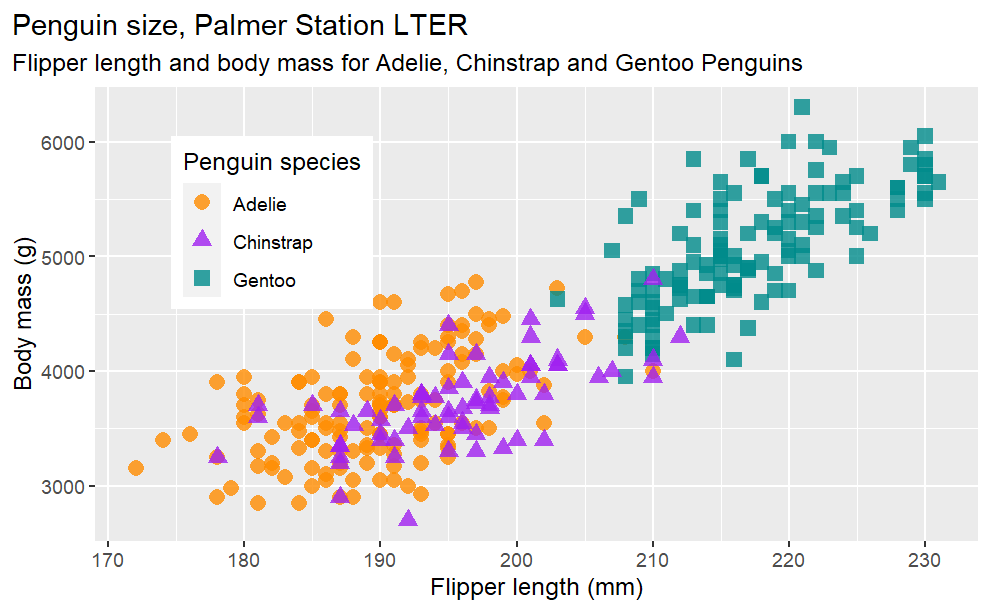

```r
mass_flipper <- ggplot(data = penguins,
                       aes(x = flipper_length_mm,
                           y = body_mass_g)) +
  geom_point(aes(color = species,
                 shape = species),
             size = 3,
             alpha = 0.8) +
  scale_color_manual(values = c("darkorange","purple","cyan4")) +
  labs(title = "Penguin size, Palmer Station LTER",
       subtitle = "Flipper length and body mass for Adelie, Chinstrap and Gentoo Penguins",
       x = "Flipper length (mm)",
       y = "Body mass (g)",
       color = "Penguin species",
       shape = "Penguin species") +
  theme(legend.position = c(0.2, 0.7),
        plot.title.position = "plot",
        plot.caption = element_text(hjust = 0, face= "italic"),
        plot.caption.position = "plot")

mass_flipper
```

Proponer un modelo en el que el peso tiene una distribución normal con parámetros MU y SIGMA, donde MU se basa en el largo de las aletas.

```r
# modelo lineal - bayes
priors =  c(
            prior(normal(75, 20), class = "b", coef ="flipper_length_mm"),
             prior(normal(0, 2000), class = "Intercept"),
            prior(exponential(0.001), class = "sigma")
             )

penguinFit <- brm(body_mass_g ~ flipper_length_mm, data =penguins,
                       family = gaussian,

                       prior = priors ,
                       chains = 4, iter = 5000*2, seed = 84735)
```

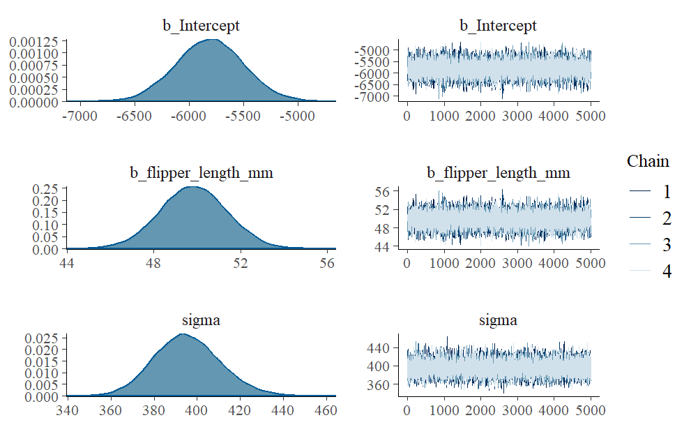

```r
plot(penguinFit)
```

El rhat me da cerca de 1, y nos dice la variabilidad entre las cadenas y la variabildad intra cadena. nos gustaria que sea parecido es decir entre 0.9 y 1.1 .

```r
rhat(penguinFit)
```

```
        b_Intercept b_flipper_length_mm               sigma
           1.000196            1.000163            1.000278
             lprior                lp__
           1.000301            1.000170
```

Numero efectivo de mustras NEFF es la proporcion, tiene que ser la mitad o mas. Es la cantidad de muestras que no estan correlacionadas. Las del warmup de las cadenas las descartas porque estan muy correlacionadas.

```r
neff_ratio(penguinFit)
```

```
        b_Intercept b_flipper_length_mm               sigma
          0.7693385           0.7535050           0.7932462
             lprior                lp__
          0.7849982           0.5397514
```

Intervalos de confianza de cada parametro

```r
tidy(penguinFit, conf.int = TRUE, conf.level = 0.95) |>
  select(-c(effect, component, group))
```

| term | estimate | std.error | conf.low | conf.high |
| --- | --- | --- | --- | --- |
| (Intercept) | -5810.79952 | 309.964505 | -6413.38903 | -5200.92931 |
| flipper_length_mm | 49.83207 | 1.541251 | 46.80928 | 52.82526 |
| sd__Observation | 395.47381 | 15.213852 | 366.94752 | 426.68031 |

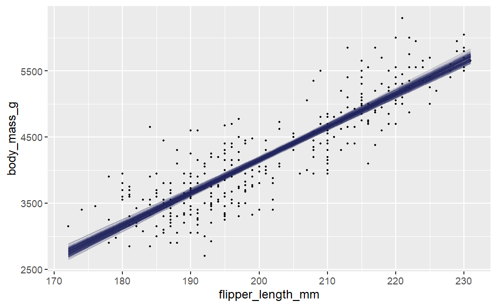

```r
penguins |>
  add_linpred_draws(penguinFit, ndraws = 100) |>
  ggplot(aes(x = flipper_length_mm, y = body_mass_g)) +
  geom_point(data = penguins, size = 0.5) +
  geom_line(aes(y = .linpred, group = .draw), alpha = 0.2, size = 0.5, color = clrs[6]) +
  labs(x = "flipper_length_mm", y = "body_mass_g")
```

Encontrar la distribución posterior para el peso esperado de un pinguino que tiene una aleta de largo 200 mm. Graficarla y dar medidas resumen.

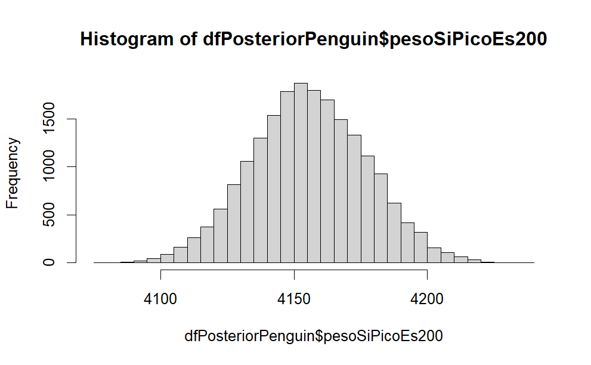

```r
dfPosteriorPenguin = posterior_samples(penguinFit)
dfPosteriorPenguin$pesoSiPicoEs200 = dfPosteriorPenguin$b_Intercept + dfPosteriorPenguin$b_flipper_length_mm*200

dfPosteriorPenguin$pesoSamplePico200 = rnorm(nrow(dfPosteriorPenguin),dfPosteriorPenguin$pesoSiPicoEs200, dfPosteriorPenguin$sigma)

hist(dfPosteriorPenguin$pesoSiPicoEs200, breaks=50) # Peso medio
```

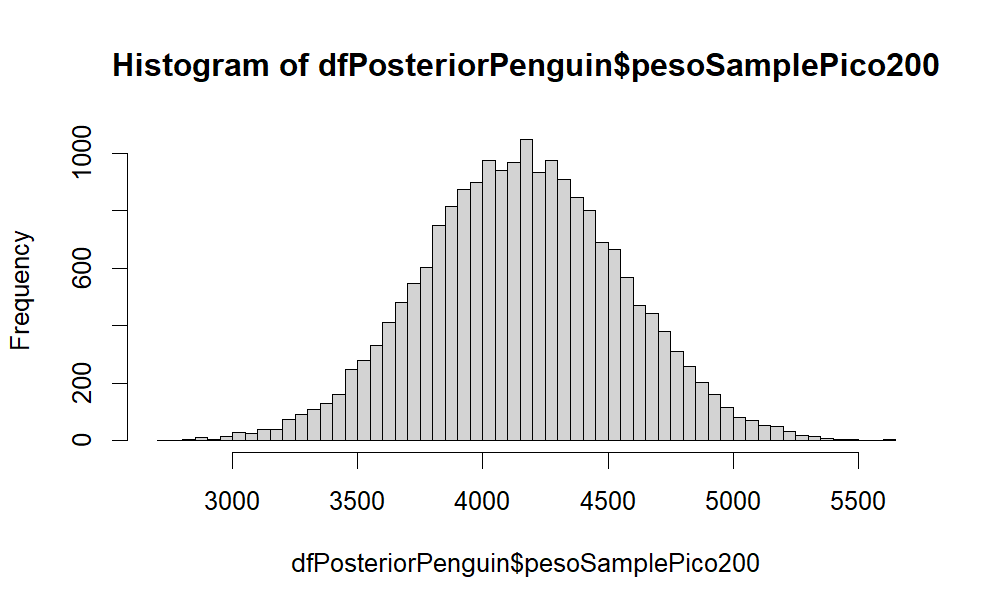

```r
hist(dfPosteriorPenguin$pesoSamplePico200, breaks=50) # peos esperado
```

```
Using all posterior draws for ppc type 'ribbon' by default.
```

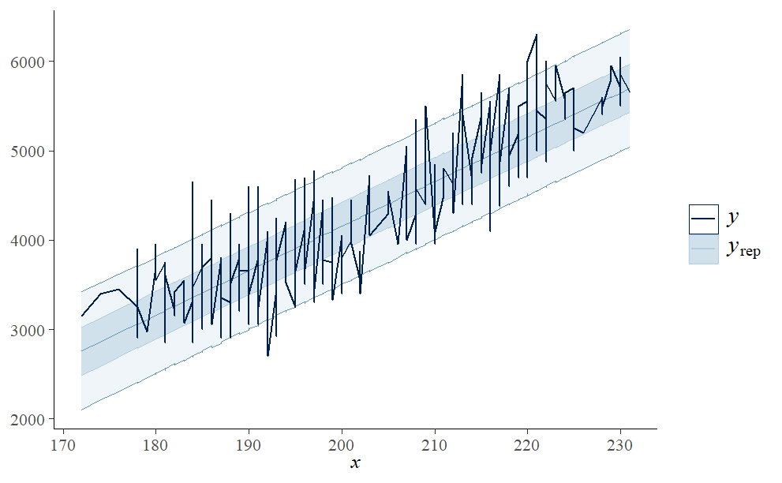

```r
pp_check(penguinFit, type = "ribbon", x = "flipper_length_mm")
```

Graficar 100 rectas correspondientes al peso esperado de pinguinos con una aleta de largo entre 150 mm y 250 mm. Hacer lo mismo para el peso predicho por el modelo.

```r
####
#pp_check(penguinFit, type = "ribbon", x = "flipper_length_mm")

xc.seq = seq(150,250,by=1)

penguins %>%
  data_grid(flipper_length_mm = xc.seq) %>%
  add_predicted_draws(penguinFit) %>%
  ggplot(aes(x = flipper_length_mm, y = body_mass_g)) +
  stat_lineribbon(aes(y = .prediction), .width = c(.999,.99, .95, .8, .5, 0.2), color = "#08519C") +
  geom_point(data = penguins, size = 1.5) +scale_fill_brewer() +
  theme_classic()
```

```
Error in data_grid(., flipper_length_mm = xc.seq) :
  could not find function "data_grid"
```

2 Proponer un modelo de regresión logística para clasificar a un pinguino como de la especie Gentoo usando como variable predictora al largo del pico (bill_length).

```r
newdata <- one_hot(as.data.table(penguins))
dfpen = na.omit(newdata[,c("species_Gentoo","bill_length_mm")])
dfpen
```

| species_Gentoo | bill_length_mm |
| --- | --- |
| 0 | 39.1 |
| 0 | 39.5 |
| 0 | 40.3 |
| 0 | 36.7 |
| 0 | 39.3 |
| 0 | 38.9 |
| 0 | 39.2 |
| 0 | 34.1 |
| 0 | 42.0 |
| 0 | 37.8 |

[output cut: 332 more lines]

```r
logisticFitPenguin <- brm(formula = species_Gentoo ~ bill_length_mm,
           data    = dfpen,
           family  = bernoulli(link = "logit"),
           prior   = c(prior(normal(0, 5), class = "Intercept"),
                       prior(normal(0, 5), class = "b", coef = "bill_length_mm")),
           iter = 1000, warmup = 500, chains = 2,)
```

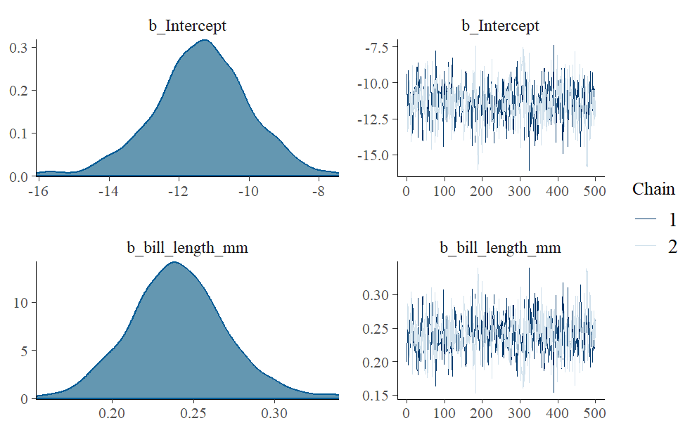

```r
plot(logisticFitPenguin)
```

```r
rhat(logisticFitPenguin)
```

```
     b_Intercept b_bill_length_mm           lprior
        1.002688         1.002677         1.003048
            lp__
        1.002535
```

```
Using all posterior draws for ppc type 'intervals' by default.
```

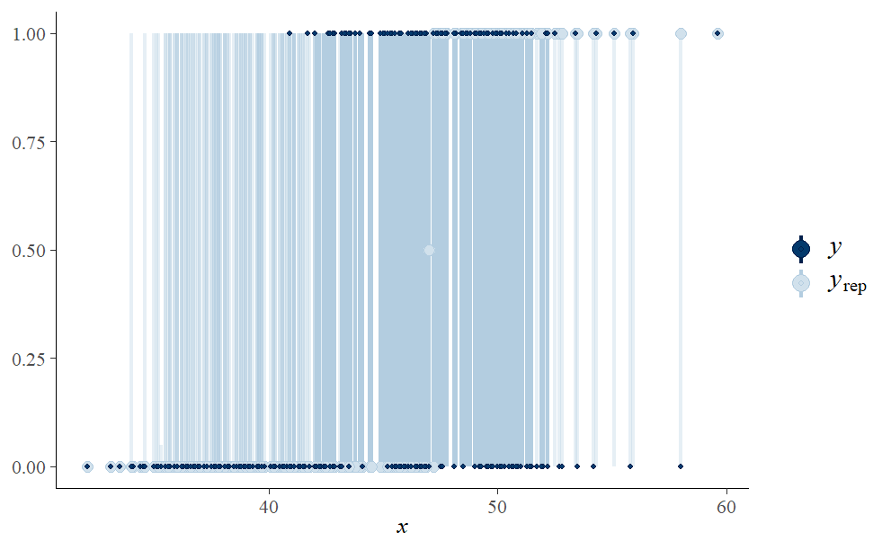

```r
pp_check(logisticFitPenguin, type = "intervals", x = "bill_length_mm")
```

Correr el modelo y extraer la probabilidad de que un pinguino sea Gentoo si su pico tiene largo 40 mm. (Ayuda: se puede usar la función posterior_linpred(transform = TRUE)).

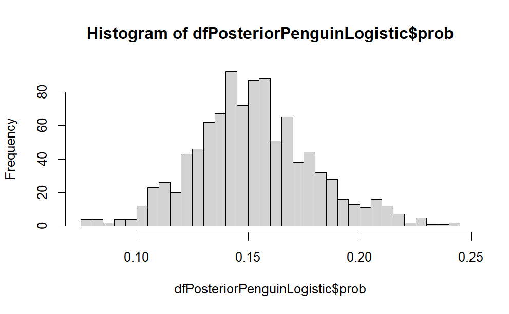

```r
dfPosteriorPenguinLogistic = posterior_samples(logisticFitPenguin)
dfPosteriorPenguinLogistic$probSinLog =  -(dfPosteriorPenguinLogistic$b_Intercept + 40*dfPosteriorPenguinLogistic$b_bill_length_mm)

#(posterior_linpred(logisticFitPenguin,transform = TRUE) )

dfPosteriorPenguinLogistic$prob = 1/(1+exp(dfPosteriorPenguinLogistic$probSinLog))
hist(dfPosteriorPenguinLogistic$prob, breaks=50)
```

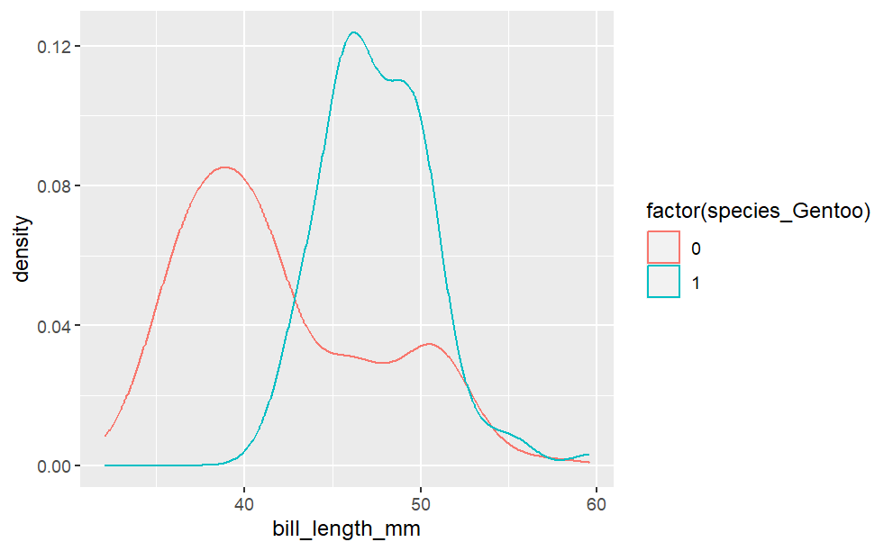

```r
# Basic density plot in ggplot2
ggplot(dfpen, aes(x = bill_length_mm, colour = factor(species_Gentoo))) +
  geom_density()
```

```r
#hist(dfpen$bill_length_mm, color=dfpen$species_Gentoo)
```

```r
table(dfpen$species_Gentoo)
```

```
  0   1
219 123
```

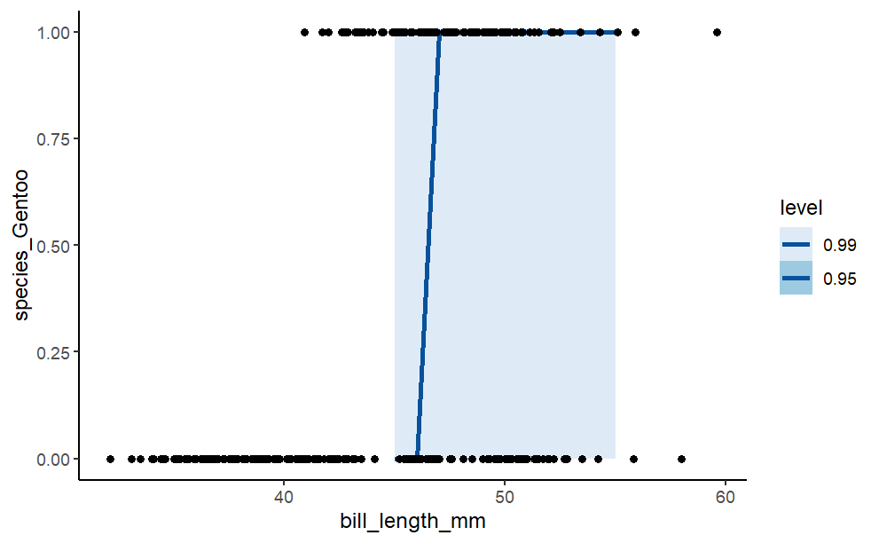

```r
xc.seq = seq(min(dfpen$bill_length_mm),max(dfpen$bill_length_mm),by=1)
xc.seq = seq(45,55, by=1)
dfpen %>%
  data_grid(bill_length_mm = xc.seq) %>%
  add_predicted_draws(logisticFitPenguin) %>%
  ggplot(aes(x = bill_length_mm, y = species_Gentoo)) +
  stat_lineribbon(aes(y = .prediction), .width = c(.99, .95), color = "#08519C") +
  geom_point(data = dfpen, size = 1.5) +scale_fill_brewer() +
  theme_classic()
```

```r
penguins3 = na.omit(penguins[,c("bill_depth_mm","bill_length_mm","flipper_length_mm")])
penguins3$r = (penguins3$bill_depth_mm / penguins3$bill_length_mm)
min(penguins3$r)
```

```
[1] 0.2768031
```

```r
priorsRatio =  c(
            prior(normal(0, 1), class = "b", coef ="r"),
             prior(normal(0, 10), class = "Intercept")
             )

penguinFitExp <- brm(flipper_length_mm ~ r, data =penguins3,
                       family = exponential(),
                       prior = priorsRatio ,
                       chains = 4, iter = 5000*2, seed = 84735)
```

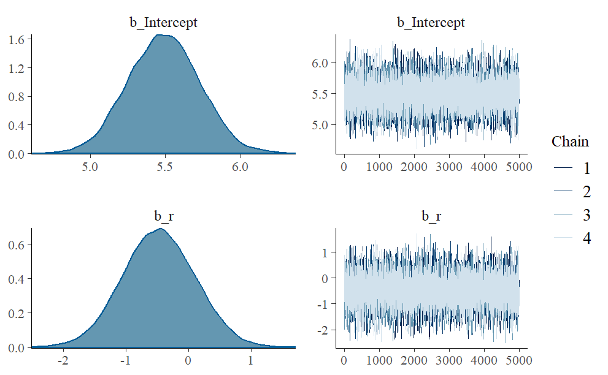

```r
plot(penguinFitExp)
```

```r
xc.seq = seq(170,240,by=1)

penguins3 %>%
  data_grid(flipper_length_mm = xc.seq, r=seq(0,1,by=0.1)) %>%
  add_predicted_draws(penguinFitExp) %>%
  ggplot(aes(x = flipper_length_mm, y = r)) +
  #+stat_lineribbon(aes(y = .prediction), .width = c(.95,0.5), color = "#08519C")
  geom_line(aes(y = .prediction), color = "#08519C") +
  geom_point(data = penguins3, size = 1.5) +scale_fill_brewer() +
  theme_classic()
```

[output not shown]